# 期末報告-第七組

0652022何若菁,0312229皇甫承佑,0487304 張家豪

2018年1月14日

# Load data

```r
library(dplyr)
library(readr)
```

```r
library(ggplot2)
library(digest)
# download data from web
url_1<- "https://docs.google.com/spreadsheets/d/e/2PACX-1vRvUUk-oL0Q6CIY8g121I7U4hqTg5jS7WNftta2fCnIUXkw7V1ARx0soXD613ShCrkFqDwRk3wCE8d7/pub?gid=0&single=true&output=csv"
download.file(url_1, destfile="104鼻咽癌資料")
cancer_data <- read_csv("104鼻咽癌資料")
dat <- select(cancer_data,'性別(5)',`診斷年齡(33)`)
names(dat) <- c("sex","age")
```

# 呈現性別、年齡資料分布型態

```r
sex_dat <- data.frame( sex = c("male","female"),
                       quantity = c(nrow(dat[dat$sex==1,1]),nrow(dat[dat$sex==2,1])))
head(sex_dat)
```

```
##      sex quantity
## 1   male       60
## 2 female       33
```

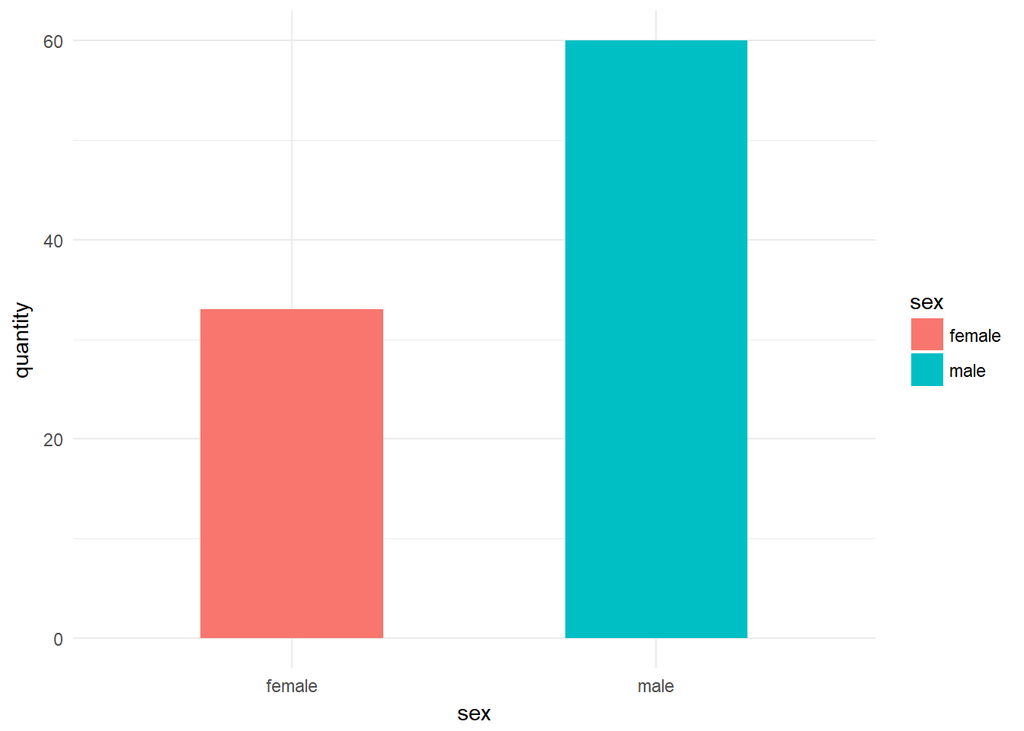

```r
sex_plot <- ggplot(data = sex_dat, aes(x = sex,y = quantity, fill = sex) ) +
            geom_bar(stat="identity", width=0.5)+theme_minimal()
print(sex_plot)
```

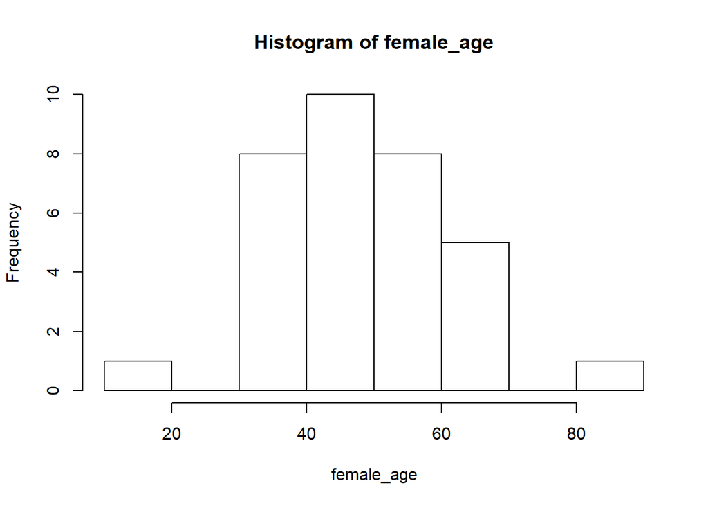

```r
female_age <- filter(dat,sex==2) %>% select(age)
female_age <- as.numeric(unlist(female_age))
male_age <- filter(dat,sex==1) %>% select(age)
male_age <- as.numeric(unlist(male_age))
female_age <- hist(female_age)
```

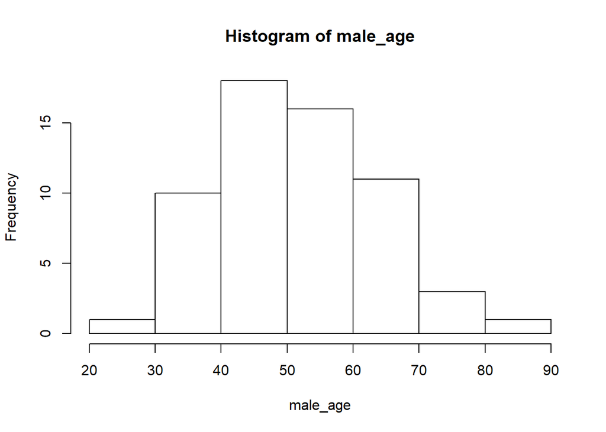

```r
male_age <- hist(male_age)
```

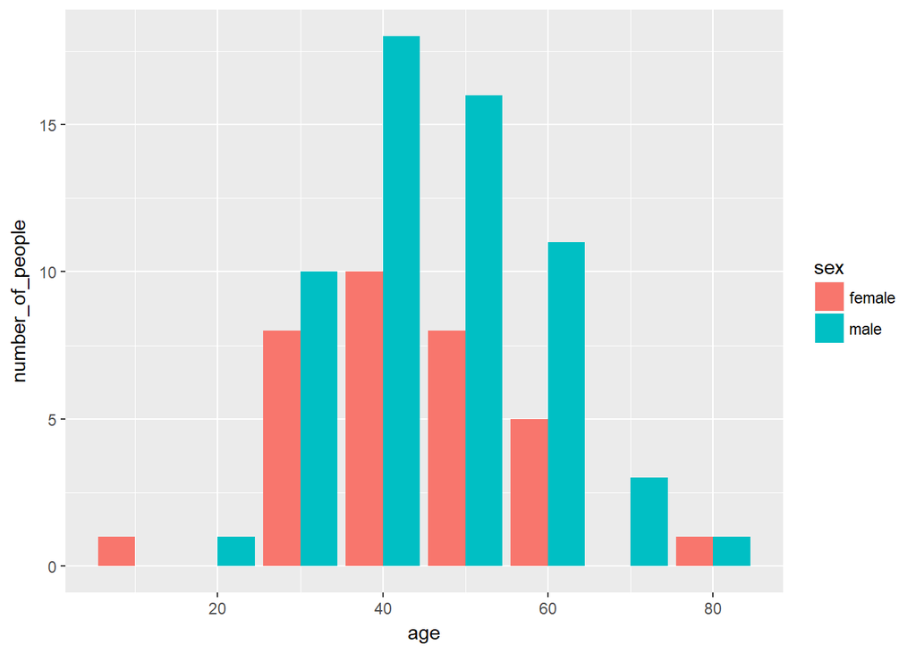

```r
len <- c(0,male_age$counts,female_age$counts)
age_dat <- data.frame( sex = rep(c("male","female"), each=8),
                       age = rep(seq(10,80,10),2),
                       number_of_people = len)
ggplot(data=age_dat, aes(x=age, y=number_of_people, fill=sex)) +
  geom_bar(stat="identity", position=position_dodge())
```

```r
head(sex_dat)
```

```
##      sex quantity
## 1   male       60
## 2 female       33
```

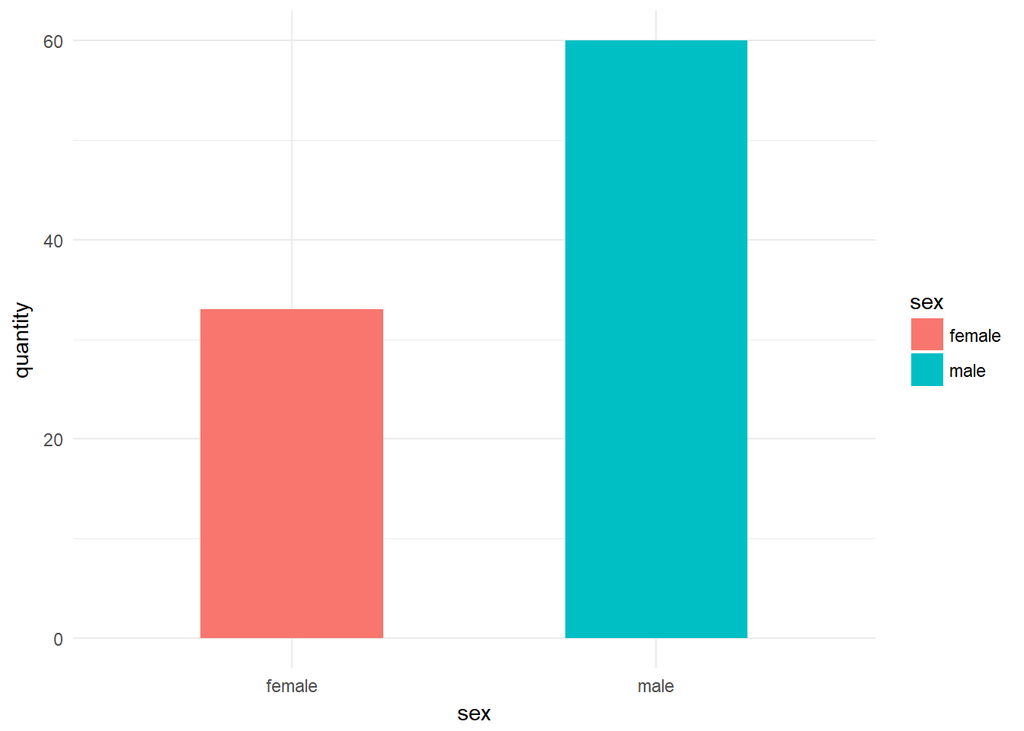

```r
age_plot <- ggplot(data = sex_dat, aes(x = age,y = quantity, fill = sex) ) +
  geom_bar(stat="identity", width=0.5)+theme_minimal()
print(sex_plot)
```

# 將病患嚴重程度量化作為評估標準

```r
severity <- select(cancer_data,'腫瘤大小(86)',`分化程度(50)`)
# preview tumor size classification
size_class <- unique(severity[,1])
size_class[size_class > 989] <- 0 #去除>989之值，找最大值做腫瘤大小的分數規則
max_size <- max(size_class)
size_grade <- round( max_size / 10 )#將腫瘤大小分為十級，每增加多少ｍｍ之腫瘤，腫瘤大小上升一級
severity[severity[,1] > 989,1] <- NA # 腫瘤大小情形沒有介於989~999之間的值，因此>989即為腫瘤大小不詳，計為ＮＡ
severity[,1] <- sapply(severity[,1], function(x){
  y = round( x/size_grade );
  return(y)
})
```

# preview tumor diffrentiation classification

分化程度有４，２，３，９四種情形腫瘤分化程度越低，惡化程度越嚴重

```r
unique(severity[,2])
```

```
## # A tibble: 4 x 1
##   `分化程度(50)`
##            <int>
## 1              4
## 2              2
## 3              3
## 4              9
```

```r
severity[severity[,2] == 4 ,2] <- 0 # 分化程度為４為未分化，計為０，９為不詳，計為ＮＡ
severity[severity[,2] == 9 ,2] <- NA
# 評量分數計算為腫瘤大小加上分化程度，若其中一項未知，則只採用其中一項，若兩者皆未知既為ＮＡ
severity <- mutate(severity,severity_result= mapply(function(x,y){
  z = ifelse(is.na(x) & is.na(y),NA,ifelse(is.na(x)|is.na(y),ifelse(is.na(x),y,x),x+y))
  return(z)
},severity[,1],severity[,2]))
```

# 將病患生活習慣量化以做評估

抽菸＝每日抽菸量*抽菸年計算

```r
smoking <- select(cancer_data,'每日吸菸量(A3-1)',`吸菸年(A3-2)`)
not_sure_q <- which( smoking[,1]==91|smoking[,1]==98 ) # 若吸菸年量不確定為９１及９８，先計為０，之後以平均值計算
not_sure_y <- which( smoking[,2]==91|smoking[,2]==98 )
smoking[smoking[,1]>90,1] <- NA # 若吸菸量不詳，為９９，計為ＮＡ
smoking[smoking[,2]>90,2] <- NA # 若吸菸年不詳，為９９，計為ＮＡ
```

若吸菸年或吸菸數量／年為不一定，以平均吸菸量/年計算

```r
smo_q_ave <- sum(smoking[,1],na.rm = T) / length(is.na(smoking[,1]))
smoking[not_sure_q,1] <- round(smo_q_ave)
smo_y_ave <- sum(smoking[,2],na.rm = T) / length(is.na(smoking[,2]))
smoking[not_sure_y,2] <- round(smo_y_ave)
```

評量分數計算為每日抽菸量*抽菸年，若其中一項未知，則只採用其中一項，若皆未知既為ＮＡ

```r
smoking <- mutate(smoking,smoke_result= mapply(function(x,y){
  z = ifelse(is.na(x) & is.na(y),NA,ifelse(is.na(x)|is.na(y),ifelse(is.na(x),y,x),x*y))
  return(z)
},smoking[,1],smoking[,2]))
```

# 將病患生活習慣量化以做評估

嚼檳榔＝每日嚼檳榔量*嚼檳榔年計算

```r
areca <- select(cancer_data,'每日嚼檳榔量(A4-1)',`嚼檳榔年(A4-2)`)
not_sure_q <- which( areca[,1]==91|areca[,1]==98 ) # 若嚼檳榔年量不確定為９１及９８，先計為０，之後以平均值計算
not_sure_y <- which( areca[,2]==91|areca[,2]==98 )
areca[areca[,1]>90,1] <- NA # 若吸菸量不詳，為９９，計為ＮＡ
areca[areca[,2]>90,2] <- NA # 若吸菸年不詳，為９９，計為ＮＡ
```

若嚼檳榔年或嚼檳榔數量／年為不一定，以平均吸菸量/年計算

```r
areca_q_ave <- sum(areca[,1],na.rm = T) / length(is.na(areca[,1]))
areca[not_sure_q,1] <- round(areca_q_ave)
areca_y_ave <- sum(areca[,2],na.rm = T) / length(is.na(areca[,2]))
areca[not_sure_y,2] <- round(areca_y_ave)

# 評量分數計算為每日嚼檳榔量*嚼檳榔年，若其中一項未知，則只採用其中一項，若皆未知既為ＮＡ
areca <- mutate(areca,areca_result= mapply(function(x,y){
  z = ifelse(is.na(x) & is.na(y),NA,ifelse(is.na(x)|is.na(y),ifelse(is.na(x),y,x),x*y))
  return(z)
},areca[,1],areca[,2]))
```

# 將病患生活習慣量化以做評估

喝酒行為則以分類計算:從未喝酒、已戒、偶爾喝(不論年數)、習慣性喝酒＜10 年、習慣性喝酒≧10 年、不明

```r
alcohol <- select(cancer_data,'喝酒行為(A5)')
alcohol[alcohol[,1]==999,1] <- NA # 若喝酒行為不詳，為９９9，計為ＮＡ
```

# 計算病患BMI以做評估分類

BMI = 體重(公斤)/身高(公尺)^2 正常BMI值介於18.5~24，若不正常設為1，正常為0

```r
BMI <- select(cancer_data,'體重(A2)','身高(A1)')
BMI[BMI[,1]==999,1] <- NA # 若體重不詳，為９９9，計為ＮＡ
BMI[BMI[,2]==999,2] <- NA # 若身高不詳，為９９9，計為ＮＡ
BMI <- mutate(BMI,BMI_result= mapply(function(x,y){
  z = ifelse(is.na(x) & is.na(y),NA,ifelse(is.na(x)|is.na(y),ifelse(is.na(x),NA,NA),x/(0.01*y)^2) )
  z = round(z)
  z = ifelse(z>=18.5&z<24,0,1)
  return(z)
},BMI[,1],BMI[,2]))
```

# Preview sex and age distribution

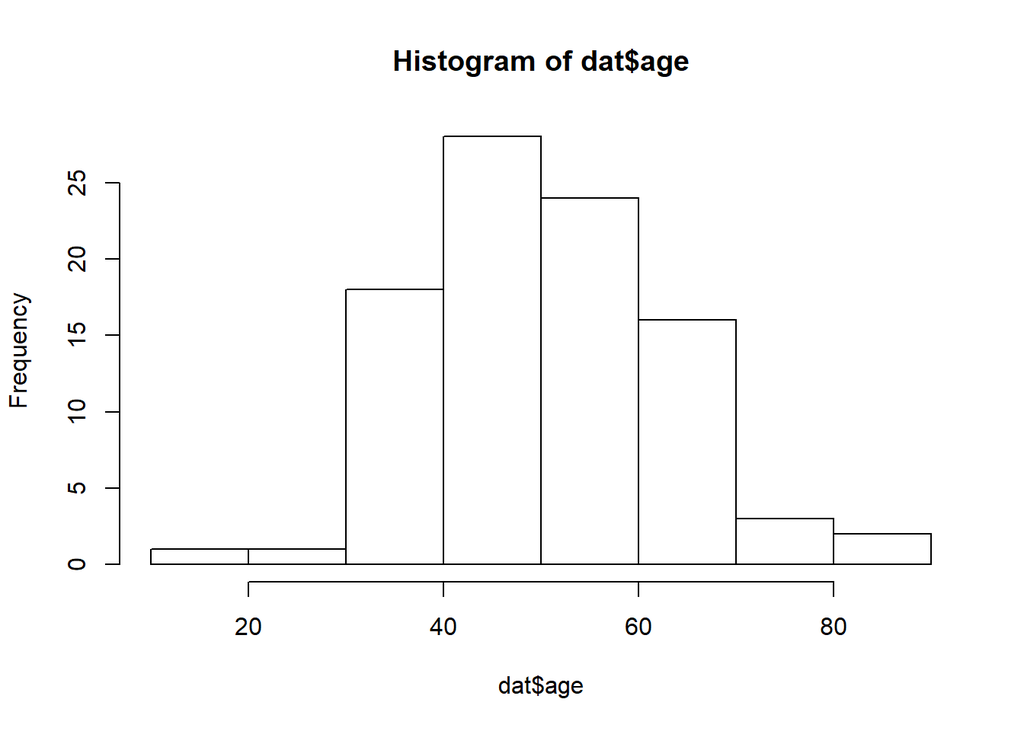

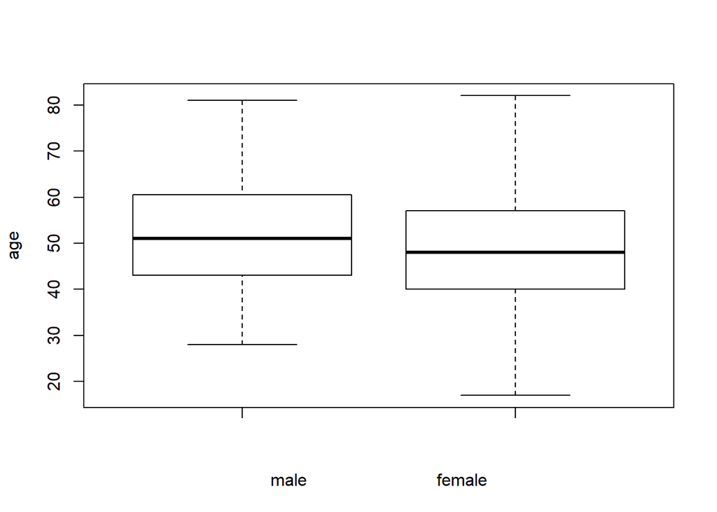

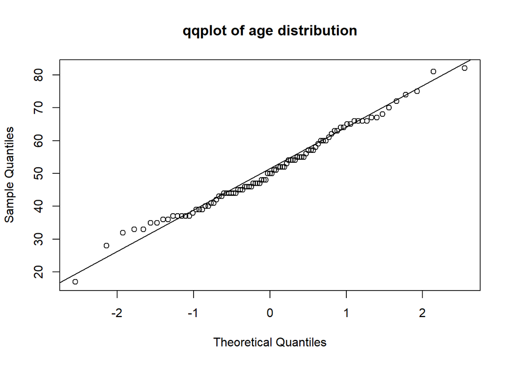

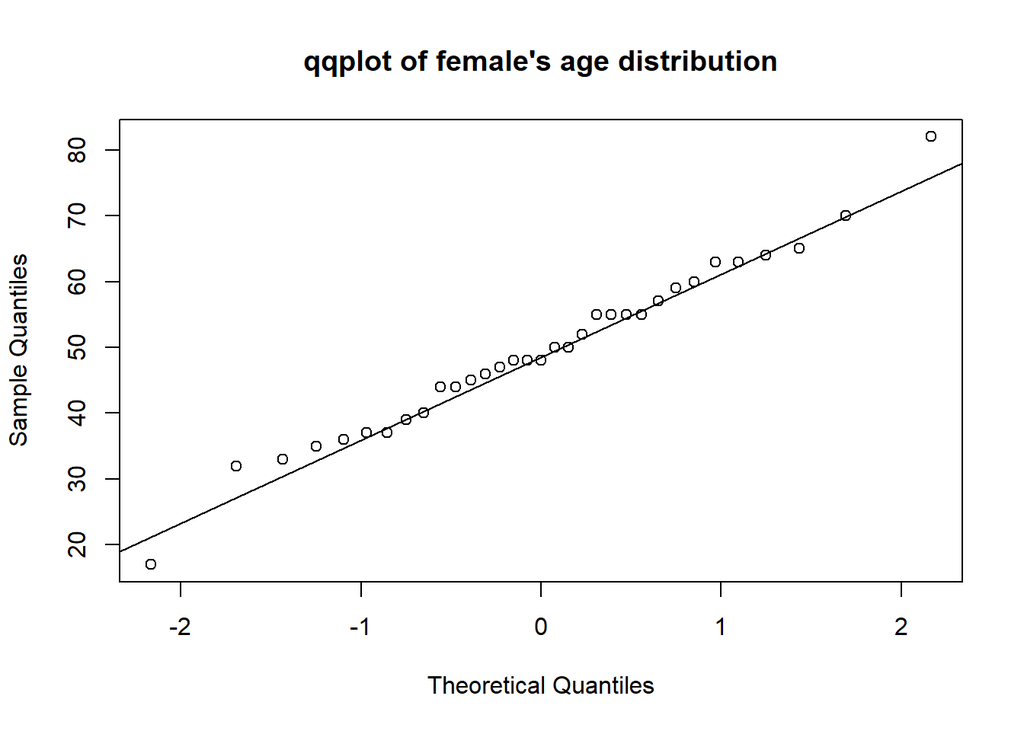

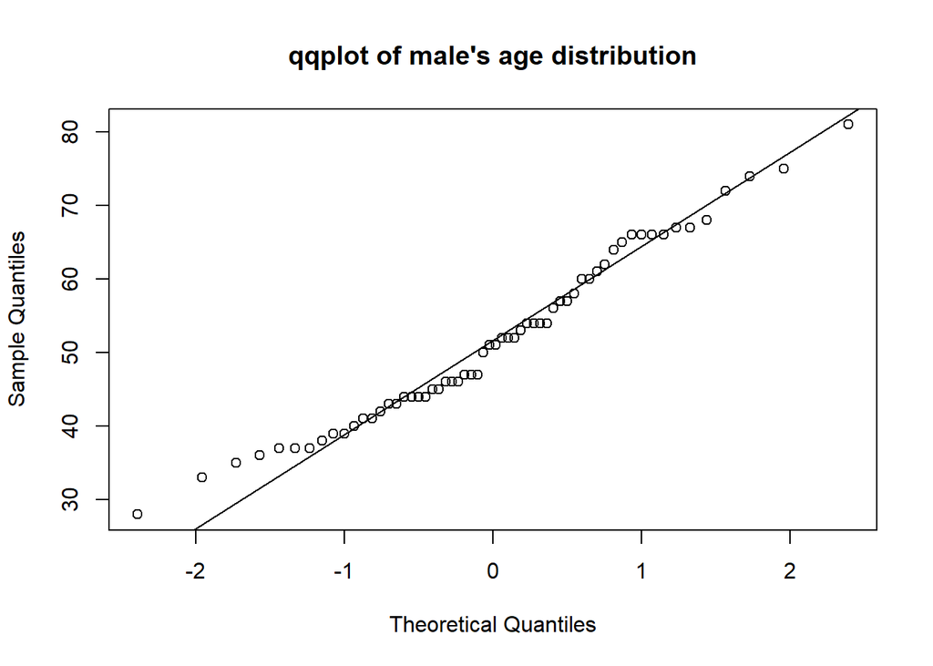

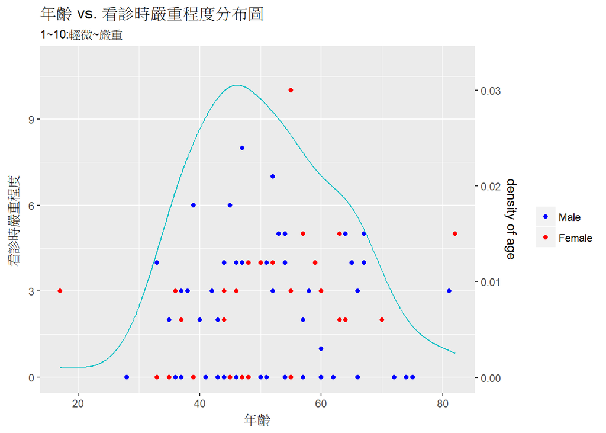

## 探討年齡與看診時嚴重程度的關聯性 Simple linear regression analysis of 年齡 on 看診時嚴重程度

```r
lm_age <- lm(dat$age~dat$severity_result)
summary(lm_age)
```

```
##
## Call:
## lm(formula = dat$age ~ dat$severity_result)
##
## Residuals:
##     Min      1Q  Median      3Q     Max
## -34.122  -7.953  -1.790   7.547  29.878
##
## Coefficients:
##                     Estimate Std. Error t value Pr(>|t|)
## (Intercept)          49.1158     1.9302   25.45   <2e-16 ***
## dat$severity_result   0.6686     0.5918    1.13    0.262
## ---
## Signif. codes:  0 '***' 0.001 '**' 0.01 '*' 0.05 '.' 0.1 ' ' 1
##
## Residual standard error: 12.2 on 81 degrees of freedom
##   (10 observations deleted due to missingness)
## Multiple R-squared:  0.01552,    Adjusted R-squared:  0.003362
## F-statistic: 1.277 on 1 and 81 DF,  p-value: 0.2619
```

斜率為為0.66，但其p-value>0.05，代表兩者線性關係不具顯著差異 此intercept代表當病患群嚴重程度皆為輕微(疾病嚴重指標=0)，病患群的年齡平均約為49歲 為確認兩者是否有相關性，將age分為老人(age>60)及年輕人(age<60)，嚴重程度分為>0及<0，使用odds ratio計算

```r
dat <- mutate(dat, senior = sapply(dat[,2],function(x){
  z = ifelse(is.na(x),NA,ifelse(x>60,1,0))
  return(z)
}))
dat <- mutate(dat, severity_ind = sapply(dat$severity_result,function(x){
  z = ifelse(is.na(x),NA,ifelse(x>0,1,0))
  return(z)
}))
# install.packages("epiR") #"gmodels","epiR" first, then load them into R
library(gmodels)
library(epiR)
TAB1<-xtabs(~dat$senior+dat$severity_ind)
TAB1
```

```
##           dat$severity_ind
## dat$senior  0  1
##          0 27 39
##          1  5 12
```

```r
epi.2by2(TAB1, method="case.control")
```

```
##              Outcome +    Outcome -      Total        Prevalence *
## Exposed +           27           39         66                40.9
## Exposed -            5           12         17                29.4
## Total               32           51         83                38.6
##                  Odds
## Exposed +       0.692
## Exposed -       0.417
## Total           0.627
##
## Point estimates and 95 % CIs:
## -------------------------------------------------------------------
## Odds ratio (W)                               1.66 (0.52, 5.26)
## Attrib prevalence *                          11.50 (-13.20, 36.19)
## Attrib prevalence in population *            9.14 (-14.92, 33.20)
## Attrib fraction (est) in exposed  (%)        39.46 (-111.88, 85.08)
## Attrib fraction (est) in population (%)      33.59 (-70.85, 74.19)
## -------------------------------------------------------------------
##  X2 test statistic: 0.754 p-value: 0.385
##  Wald confidence limits
##  * Outcomes per 100 population units
```

OR不等於1之p-value=0.385，表示兩者並無顯著相關性 考慮有可能是因為年齡組群人數差異的關係(老年17人、年輕66人)，降低老年門檻重新計算一次 以年齡平均值51作為老年門檻，使得人數分群平均

```r
dat <- mutate(dat, senior2 = sapply(dat[,2],function(x){
  z = ifelse(is.na(x),NA,ifelse(x>51,1,0))
  return(z)
}))
TAB2<-xtabs(~dat$senior2+dat$severity_ind)
TAB2
```

```
##            dat$severity_ind
## dat$senior2  0  1
##           0 22 24
##           1 10 27
```

```r
epi.2by2(TAB2, method="case.control")
```

```
##              Outcome +    Outcome -      Total        Prevalence *
## Exposed +           22           24         46                47.8
## Exposed -           10           27         37                27.0
## Total               32           51         83                38.6
##                  Odds
## Exposed +       0.917
## Exposed -       0.370
## Total           0.627
##
## Point estimates and 95 % CIs:
## -------------------------------------------------------------------
## Odds ratio (W)                               2.48 (0.98, 6.26)
## Attrib prevalence *                          20.80 (0.47, 41.13)
## Attrib prevalence in population *            11.53 (-6.20, 29.26)
## Attrib fraction (est) in exposed  (%)        59.15 (-11.58, 85.80)
## Attrib fraction (est) in population (%)      40.97 (-4.94, 66.80)
## -------------------------------------------------------------------
##  X2 test statistic: 3.745 p-value: 0.053
##  Wald confidence limits
##  * Outcomes per 100 population units
```

OR不等於1之p-value下降到0.053，但仍然高於0.05，表示兩者並無顯著相關性 推論一:人群變多之後p-value就明顯下降且趨近0.05，前者以年齡>60做分類若人數變多可能就可以有顯著區別。 推論二:以年齡>50雖然使得兩群人數較接近，但也可能這個門檻本身就無法把老年和青壯年很好地分別

# 將outcome改為sevrity>0探討不同年齡層嚴重程度的影響

```r
age1 <- rep(0, nrow(dat))
age1[dat[,2]<61]<-1

ill<- rep(0, nrow(dat))
ill[!is.na(dat[,5]) & dat[,5]>0]<-1
ill[is.na(dat[,5])]<-NA

lm_age2 <- glm(ill~age1,family = binomial, na.action = na.omit)
summary(lm_age2)
```

```
##
## Call:
## glm(formula = ill ~ age1, family = binomial, na.action = na.omit)
##
## Deviance Residuals:
##     Min       1Q   Median       3Q      Max
## -1.5645  -1.3370   0.8346   1.0258   1.0258
##
## Coefficients:
##             Estimate Std. Error z value Pr(>|z|)
## (Intercept)   0.8755     0.5323   1.645    0.100
## age1         -0.5077     0.5882  -0.863    0.388
##
## (Dispersion parameter for binomial family taken to be 1)
##
##     Null deviance: 110.67  on 82  degrees of freedom
## Residual deviance: 109.90  on 81  degrees of freedom
##   (10 observations deleted due to missingness)
## AIC: 113.9
##
## Number of Fisher Scoring iterations: 4
```

```r
exp(-0.5077)
```

```
## [1] 0.6018783
```

exp(alpha1) = 0.6意涵年齡<=60對於年齡>60的病患，嚴重程度大的勝算比=0.6 然而，其p-vlaue>0.005，表示此差距不具顯著性。驗證即使年齡門檻設在60，年齡與看診時嚴重程度並無相關性 ## 探討吸菸行為與看診時嚴重程度的關聯性 Simple linear regression analysis of 吸菸行為 on 看診時嚴重程度

```r
lm_smoke <- glm(ill~dat$smoke_result+dat$BMI_result,family = binomial,na.action = na.omit)
summary(lm_smoke)
```

```
##
## Call:
## glm(formula = ill ~ dat$smoke_result + dat$BMI_result, family = binomial,
##     na.action = na.omit)
##
## Deviance Residuals:
##     Min       1Q   Median       3Q      Max
## -1.4329  -1.1123   0.9418   0.9525   1.4912
##
## Coefficients:
##                    Estimate Std. Error z value Pr(>|z|)
## (Intercept)      -0.3407537  0.5409402  -0.630    0.529
## dat$smoke_result -0.0009302  0.0008704  -1.069    0.285
## dat$BMI_result    0.9238743  0.6271192   1.473    0.141
##
## (Dispersion parameter for binomial family taken to be 1)
##
##     Null deviance: 70.524  on 50  degrees of freedom
## Residual deviance: 67.054  on 48  degrees of freedom
##   (42 observations deleted due to missingness)
## AIC: 73.054
##
## Number of Fisher Scoring iterations: 4
```

比較代入各種參數算出來的AIC值，考慮BMI狀況下嚴重程度和吸菸關係之AIC最小。

```r
exp(-0.0009302)
```

```
## [1] 0.9990702
```

有吸菸行為的人，在ＢＭＩ情況相同下比沒有嚼時檳榔者有0.99之勝算比疾病較嚴重，但是P-value過大，表示此差別不具顯著性 ## 探討嚼檳榔行為與看診時嚴重程度的關聯性 Simple linear regression analysis of 嚼檳榔行為 on 看診時嚴重程度

```r
lm_areca <- glm(ill~dat$areca_result+dat$BMI_result,family = binomial,na.action = na.omit)
summary(lm_areca)
```

```
##
## Call:
## glm(formula = ill ~ dat$areca_result + dat$BMI_result, family = binomial,
##     na.action = na.omit)
##
## Deviance Residuals:
##     Min       1Q   Median       3Q      Max
## -1.4013  -0.9742   0.9689   0.9723   1.4720
##
## Coefficients:
##                  Estimate Std. Error z value Pr(>|z|)
## (Intercept)      -0.49873    0.51673  -0.965    0.334
## dat$areca_result -0.00857    0.01126  -0.761    0.447
## dat$BMI_result    1.01111    0.63218   1.599    0.110
##
## (Dispersion parameter for binomial family taken to be 1)
##
##     Null deviance: 69.235  on 49  degrees of freedom
## Residual deviance: 63.955  on 47  degrees of freedom
##   (43 observations deleted due to missingness)
## AIC: 69.955
##
## Number of Fisher Scoring iterations: 8
```

比較代入各種參數算出來的AIC值，考慮BMI狀況下嚴重程度和嚼檳榔關係之AIC最小。

```r
exp(-0.00857)
```

```
## [1] 0.9914666
```

有嚼檳榔行為的人，在ＢＭＩ情況相同下比沒有嚼時檳榔者有0.99之勝算比疾病較嚴重，但是P-value過大，表示此差別不具顯著性 ## 探討喝酒行為與看診時嚴重程度的關聯性 Simple linear regression analysis of 喝酒行為 on 看診時嚴重程度

```r
lm_alcohol <- glm(ill~dat$`喝酒行為(A5)`+dat$BMI_result,family = binomial,na.action = na.omit)
summary(lm_alcohol)
```

```
##
## Call:
## glm(formula = ill ~ dat$`喝酒行為(A5)` + dat$BMI_result, family = binomial,
##     na.action = na.omit)
##
## Deviance Residuals:
##    Min      1Q  Median      3Q     Max
## -1.454  -1.007   0.924   0.924   1.891
##
## Coefficients:
##                    Estimate Std. Error z value Pr(>|z|)
## (Intercept)         -0.4157     0.5239  -0.793    0.428
## dat$`喝酒行為(A5)`  -0.2973     0.2253  -1.319    0.187
## dat$BMI_result       1.0460     0.6454   1.621    0.105
##
## (Dispersion parameter for binomial family taken to be 1)
##
##     Null deviance: 69.235  on 49  degrees of freedom
## Residual deviance: 65.024  on 47  degrees of freedom
##   (43 observations deleted due to missingness)
## AIC: 71.024
##
## Number of Fisher Scoring iterations: 4
```

比較代入各種參數算出來的AIC值，考慮BMI狀況下嚴重程度和喝酒關係之AIC最小。

```r
exp(-0.2973)
```

```
## [1] 0.7428211
```

```r
BMI_alcohol <- mapply(function(x,y){
  z = ifelse(is.na(x) | is.na(y),NA,ifelse(x>0 & y>0,1,0))
  z = round(z)
  return(z)
},dat[,11],dat[,12])

BMI_smoke <- mapply(function(x,y){
  z = ifelse(is.na(x) | is.na(y),NA,ifelse(x>0 & y>0,1,0))
  z = round(z)
  return(z)
},dat[,11],dat[,8])

BMI_areca <- mapply(function(x,y){
  z = ifelse(is.na(x) | is.na(y),NA,ifelse(x>0 & y>0,1,0))
  z = round(z)
  return(z)
},dat[,11],dat[,15])

lm_life1 <- glm(ill~BMI_alcohol,family = binomial, na.action = na.omit)
summary(lm_life1)
```

```
##
## Call:
## glm(formula = ill ~ BMI_alcohol, family = binomial, na.action = na.omit)
##
## Deviance Residuals:
##    Min      1Q  Median      3Q     Max
## -1.268  -1.268   1.089   1.089   1.323
##
## Coefficients:
##             Estimate Std. Error z value Pr(>|z|)
## (Intercept)   0.2113     0.3263   0.648    0.517
## BMI_alcohol  -0.5478     0.6703  -0.817    0.414
##
## (Dispersion parameter for binomial family taken to be 1)
##
##     Null deviance: 69.235  on 49  degrees of freedom
## Residual deviance: 68.558  on 48  degrees of freedom
##   (43 observations deleted due to missingness)
## AIC: 72.558
##
## Number of Fisher Scoring iterations: 4
```

```r
lm_life2 <- glm(ill~BMI_smoke,family = binomial, na.action = na.omit)
summary(lm_life2)
```

```
##
## Call:
## glm(formula = ill ~ BMI_smoke, family = binomial, na.action = na.omit)
##
## Deviance Residuals:
##    Min      1Q  Median      3Q     Max
## -1.332  -1.177   1.030   1.177   1.177
##
## Coefficients:
##               Estimate Std. Error z value Pr(>|z|)
## (Intercept) -2.813e-16  3.430e-01   0.000    1.000
## BMI_smoke    3.567e-01  6.004e-01   0.594    0.552
##
## (Dispersion parameter for binomial family taken to be 1)
##
##     Null deviance: 70.524  on 50  degrees of freedom
## Residual deviance: 70.169  on 49  degrees of freedom
##   (42 observations deleted due to missingness)
## AIC: 74.169
##
## Number of Fisher Scoring iterations: 4
```

```r
lm_life3 <- glm(ill~BMI_areca,family = binomial, na.action = na.omit)
summary(lm_life3)
```

```
##
## Call:
## glm(formula = ill ~ BMI_areca, family = binomial, na.action = na.omit)
##
## Deviance Residuals:
##    Min      1Q  Median      3Q     Max
## -1.302  -1.177   1.058   1.177   1.177
##
## Coefficients:
##             Estimate Std. Error z value Pr(>|z|)
## (Intercept)   0.0000     0.3333   0.000     1.00
## BMI_areca     0.2877     0.6346   0.453     0.65
##
## (Dispersion parameter for binomial family taken to be 1)
##
##     Null deviance: 69.235  on 49  degrees of freedom
## Residual deviance: 69.028  on 48  degrees of freedom
##   (43 observations deleted due to missingness)
## AIC: 73.028
##
## Number of Fisher Scoring iterations: 3
```

```r
which.min(list(AIC(lm_life1),AIC(lm_life2),AIC(lm_life3),AIC(lm_areca),AIC(lm_alcohol),AIC(lm_smoke)))
```

```
## [1] 4
```

## 加入考慮性別的因素

```r
dat[dat$sex==2,1] <- 0 # 將ｓｅｘ＝２為女性改為０方便做logistic regression
lm_sex <- glm(ill~dat$sex,family = binomial,na.action = na.omit)
summary(lm_sex)
```

```
##
## Call:
## glm(formula = ill ~ dat$sex, family = binomial, na.action = na.omit)
##
## Deviance Residuals:
##    Min      1Q  Median      3Q     Max
## -1.530  -1.307   0.862   1.054   1.054
##
## Coefficients:
##             Estimate Std. Error z value Pr(>|z|)
## (Intercept)   0.7985     0.4014   1.989   0.0467 *
## dat$sex      -0.5000     0.4867  -1.027   0.3042
## ---
## Signif. codes:  0 '***' 0.001 '**' 0.01 '*' 0.05 '.' 0.1 ' ' 1
##
## (Dispersion parameter for binomial family taken to be 1)
##
##     Null deviance: 110.67  on 82  degrees of freedom
## Residual deviance: 109.59  on 81  degrees of freedom
##   (10 observations deleted due to missingness)
## AIC: 113.59
##
## Number of Fisher Scoring iterations: 4
```

```r
exp(0.7985)
```

```
## [1] 2.222205
```

```r
TAB2<-xtabs(~dat$sex+dat$BMI_result)
TAB2
```

```
##        dat$BMI_result
## dat$sex  0  1
##       0  9  8
##       1  8 28
```

```r
epi.2by2(TAB2, method="case.control")
```

```
##              Outcome +    Outcome -      Total        Prevalence *
## Exposed +            9            8         17                52.9
## Exposed -            8           28         36                22.2
## Total               17           36         53                32.1
##                  Odds
## Exposed +       1.125
## Exposed -       0.286
## Total           0.472
##
## Point estimates and 95 % CIs:
## -------------------------------------------------------------------
## Odds ratio (W)                               3.94 (1.15, 13.53)
## Attrib prevalence *                          30.72 (3.38, 58.06)
## Attrib prevalence in population *            9.85 (-8.65, 28.36)
## Attrib fraction (est) in exposed  (%)        73.85 (-3.60, 93.80)
## Attrib fraction (est) in population (%)      39.50 (-3.16, 64.51)
## -------------------------------------------------------------------
##  X2 test statistic: 5.001 p-value: 0.025
##  Wald confidence limits
##  * Outcomes per 100 population units
```

odds ratio = 3.94：男性比女性ＢＭＩ不正常的勝算比，p-value<0.05，具代表性

```r
lm_sex_bmi<-glm(dat$sex~ill+dat$BMI_result+age1,family = binomial,na.action = na.omit)
summary(lm_sex_bmi)
```

```
##
## Call:
## glm(formula = dat$sex ~ ill + dat$BMI_result + age1, family = binomial,
##     na.action = na.omit)
##
## Deviance Residuals:
##     Min       1Q   Median       3Q      Max
## -1.9950  -0.8921   0.6076   0.8108   1.4926
##
## Coefficients:
##                Estimate Std. Error z value Pr(>|z|)
## (Intercept)      0.8353     0.9569   0.873   0.3827
## ill             -0.6522     0.6693  -0.974   0.3299
## dat$BMI_result   1.6598     0.6940   2.392   0.0168 *
## age1            -0.8992     0.9593  -0.937   0.3486
## ---
## Signif. codes:  0 '***' 0.001 '**' 0.01 '*' 0.05 '.' 0.1 ' ' 1
##
## (Dispersion parameter for binomial family taken to be 1)
##
##     Null deviance: 66.508  on 52  degrees of freedom
## Residual deviance: 59.882  on 49  degrees of freedom
##   (40 observations deleted due to missingness)
## AIC: 67.882
##
## Number of Fisher Scoring iterations: 4
```

```r
exp(1.6598)
```

```
## [1] 5.258259
```

```r
lm_sex_bmi1 <-glm(dat$sex~ill+dat$BMI_result,family = binomial,na.action = na.omit)
summary(lm_sex_bmi1)
```

```
##
## Call:
## glm(formula = dat$sex ~ ill + dat$BMI_result, family = binomial,
##     na.action = na.omit)
##
## Deviance Residuals:
##     Min       1Q   Median       3Q      Max
## -1.9018  -0.9885   0.5983   0.7749   1.3789
##
## Coefficients:
##                Estimate Std. Error z value Pr(>|z|)
## (Intercept)      0.1180     0.5567   0.212   0.8322
## ill             -0.5801     0.6572  -0.883   0.3774
## dat$BMI_result   1.5115     0.6629   2.280   0.0226 *
## ---
## Signif. codes:  0 '***' 0.001 '**' 0.01 '*' 0.05 '.' 0.1 ' ' 1
##
## (Dispersion parameter for binomial family taken to be 1)
##
##     Null deviance: 66.508  on 52  degrees of freedom
## Residual deviance: 60.842  on 50  degrees of freedom
##   (40 observations deleted due to missingness)
## AIC: 66.842
##
## Number of Fisher Scoring iterations: 4
```

去除年齡分層變因後，回歸結果幾乎相同，年齡６０分層對此關係幾乎沒有任何作用

```r
lm_sex_bmi2 <-glm(dat$sex~dat$BMI_result+age1,family = binomial,na.action = na.omit)
summary(lm_sex_bmi2)
```

```
##
## Call:
## glm(formula = dat$sex ~ dat$BMI_result + age1, family = binomial,
##     na.action = na.omit)
##
## Deviance Residuals:
##     Min       1Q   Median       3Q      Max
## -2.0544  -1.0508   0.7317   0.7317   1.3095
##
## Coefficients:
##                Estimate Std. Error z value Pr(>|z|)
## (Intercept)      0.4946     0.8791   0.563    0.574
## dat$BMI_result   1.4865     0.6539   2.273    0.023 *
## age1            -0.8000     0.9438  -0.848    0.397
## ---
## Signif. codes:  0 '***' 0.001 '**' 0.01 '*' 0.05 '.' 0.1 ' ' 1
##
## (Dispersion parameter for binomial family taken to be 1)
##
##     Null deviance: 66.508  on 52  degrees of freedom
## Residual deviance: 60.869  on 50  degrees of freedom
##   (40 observations deleted due to missingness)
## AIC: 66.869
##
## Number of Fisher Scoring iterations: 4
```

```r
exp(1.48)
```

```
## [1] 4.392946
```

```r
sex_ill <- mapply(function(x,y){
  z = ifelse(is.na(x) | is.na(y),NA,ifelse(x>0 & y>0,1,0))
  z = round(z)
  return(z)
},dat[,1],dat[,5])


lm_sex_smo<-glm(BMI_smoke~dat$sex,family = binomial,na.action = na.omit)
summary(lm_sex_smo)
```

```
##
## Call:
## glm(formula = BMI_smoke ~ dat$sex, family = binomial, na.action = na.omit)
##
## Deviance Residuals:
##      Min        1Q    Median        3Q       Max
## -1.15324  -1.15324  -0.00013   1.20178   1.20178
##
## Coefficients:
##             Estimate Std. Error z value Pr(>|z|)
## (Intercept)   -18.57    1630.66  -0.011    0.991
## dat$sex        18.51    1630.66   0.011    0.991
##
## (Dispersion parameter for binomial family taken to be 1)
##
##     Null deviance: 64.924  on 50  degrees of freedom
## Residual deviance: 48.492  on 49  degrees of freedom
##   (42 observations deleted due to missingness)
## AIC: 52.492
##
## Number of Fisher Scoring iterations: 17
```

```r
lm_sex_alc<-glm(BMI_alcohol~dat$sex,family = binomial,na.action = na.omit)
summary(lm_sex_alc)
```

```
##
## Call:
## glm(formula = BMI_alcohol ~ dat$sex, family = binomial, na.action = na.omit)
##
## Deviance Residuals:
##      Min        1Q    Median        3Q       Max
## -0.93308  -0.93308  -0.00008  -0.00008   1.44323
##
## Coefficients:
##             Estimate Std. Error z value Pr(>|z|)
## (Intercept)   -19.57    2688.50  -0.007    0.994
## dat$sex        18.96    2688.50   0.007    0.994
##
## (Dispersion parameter for binomial family taken to be 1)
##
##     Null deviance: 55.108  on 49  degrees of freedom
## Residual deviance: 44.149  on 48  degrees of freedom
##   (43 observations deleted due to missingness)
## AIC: 48.149
##
## Number of Fisher Scoring iterations: 18
```

```r
lm_sex_are<-glm(BMI_areca~dat$sex,family = binomial,na.action = na.omit)
summary(lm_sex_are)
```

```
##
## Call:
## glm(formula = BMI_areca ~ dat$sex, family = binomial, na.action = na.omit)
##
## Deviance Residuals:
##      Min        1Q    Median        3Q       Max
## -1.03017  -1.03017  -0.00008   1.33214   1.33214
##
## Coefficients:
##             Estimate Std. Error z value Pr(>|z|)
## (Intercept)   -19.57    2688.50  -0.007    0.994
## dat$sex        19.21    2688.50   0.007    0.994
##
## (Dispersion parameter for binomial family taken to be 1)
##
##     Null deviance: 59.295  on 49  degrees of freedom
## Residual deviance: 46.070  on 48  degrees of freedom
##   (43 observations deleted due to missingness)
## AIC: 50.07
##
## Number of Fisher Scoring iterations: 18
```

以上也並未看到生活行為與性別的顯著關係

鼻咽癌的治療方式有兩種 1.放射治療是用高能量之游離輻射來破壞癌細胞，防止細胞的生長與分裂，而達到控制癌症的目的 2.化學治療是運用抗癌藥物去破壞細胞生長和繁殖的能力，達到治癒的目標。  
專家說：以放射治療或合併化學治療最有效。是真的嗎？  
讓我們用抽到的樣本來檢驗這句話的真偽！

```r
NT4811 <- cancer_data[,c(3,4,6,7,8,9,10,12,17,58,73)]
```

```r
Raditherapy <- NT4811$`放射治療開始日期(138)`
Raditherapy[Raditherapy == "0000000"] <- "0"
Raditherapy[Raditherapy != "0"] <- "1"
Raditherapy <- as.numeric((as.character(Raditherapy)))
#Raditherapy表示化學治療，"0"代表無接受，"1"代表有接受
```

```r
Chemotherapy <- NT4811$`申報醫院化學治療(163)`
Chemotherapy[Chemotherapy == "00"] <- "0"
Chemotherapy[Chemotherapy != "0"] <- "1"
Chemotherapy <- as.numeric(as.character(Chemotherapy))
#Chemotherapy表示化學治療，"0"代表無接受，"1"代表有接受
```

```r
period_to_day <- function(x){
  as.numeric(x)
  y = floor(x/10000)
  m = floor((x/10000 - y)*100)
  d = (((x/10000 - y)*100)%%1)*100
  y <- as.numeric(y)
  m <- as.numeric(m)
  d <- as.numeric(d)
  print(365*y+30*m+1*d)

}
#造一個函數，可使年/月/日轉換成日，例如：1000101轉換成36531(36500+30+1)
```

```r
start_day <- NT4811$`首次就診日(44)`
start_day <- as.numeric(as.character(start_day))
end_day <- NT4811$`最後聯絡日(30)`
end_day <- as.numeric(as.character(end_day))
#將首次就診到最後聯絡之間的時間視為存活時間。
Survival_day <- c(1:93)
for(i in c(1:93)){
  start_day[i]<- period_to_day(start_day[i])
  end_day[i] <- period_to_day(end_day[i])
  Survival_day[i] <- (end_day[i]-start_day[i])
}
```

[output not shown]

[output cut: 171 more lines]

```r
#計算出存活時間(日)，並記為survival_day
#若為0天，可能代表1.確診時就已經死亡，或是2.確診後不想治療，所以最後聯絡日和首次就診日相同。
```

```r
Status <- NT4811$`生存狀態(27)`
```

```r
NNT4811 <- data.frame(Raditherapy,Chemotherapy,Survival_day,Status)
View(NNT4811)
```

由此圖可見，大部分的人可以存活500天以上

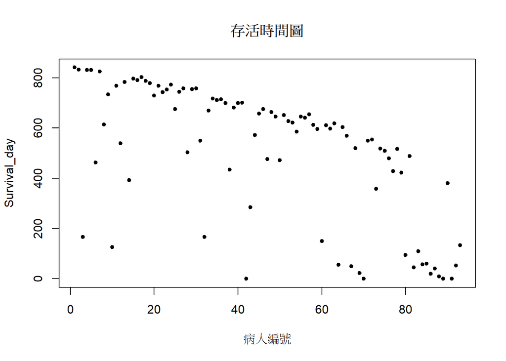

```r
plot(x=Survival_day,xlab = "病人編號",main="存活時間圖",pch = 20)
```

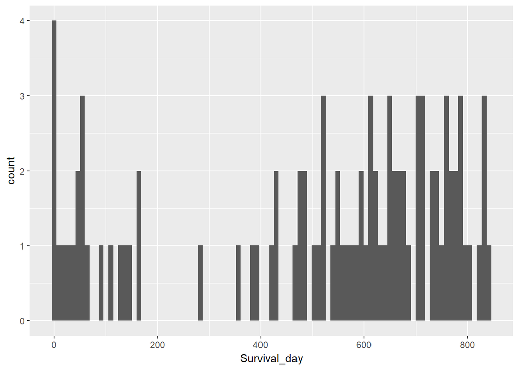

```r
ggplot(NNT4811, aes(Survival_day)) +
  geom_histogram(bins = 93)
```

#接下來要做的是用logistic回歸

```r
#是否存活超過半年(183)天？是=1，否=0
year05 <- Survival_day
year05[year05 > 183] <- 1
year05[year05 != 1] <- 0

#是否存活超過一年(365)天？是=1，否=0
year1 <- Survival_day
year1[year1 > 365] <- 1
year1[year1 != 1] <- 0

#是否存活超過兩年(730)天？是=1，否=0
year2 <- Survival_day
year2[year2 > 730] <- 1
year2[year2 != 1] <- 0

Age <- NT4811$`診斷年齡(33)`
Age <- as.numeric(Age)
NNNT4811 <-data.frame(Raditherapy,Chemotherapy,Age,Survival_day,year05,year1,year2,Status)
View(NNNT4811)
```